# Homework 4 - Machine Learning and Parallel Computing

## Due Date

March 29, 2026 by 11:59pm.

## Learning Objectives

- Apply feature engineering to prepare a real-world dataset for modelling.
- Tune hyperparameters correctly using cross-validation on the training set.
- Compare ML models on a regression task.
- Parallelize embarrassingly parallel workloads using `joblib`.

## Deliverables

Please answer all questions and interpret your findings. Upload both the `.qmd` and rendered `.html` to Quercus.

## Part 1: Machine Learning with the Ames Housing Dataset

The [Ames Housing Dataset](https://www.kaggle.com/c/house-prices-advanced-regression-techniques/data) contains 81 features describing residential properties sold in Ames, Iowa between 2006 and 2010. Our goal is to predict `SalePrice`. Please use fetch_openml to get the data from OpenML rather than Kaggle, https://www.openml.org/search?type=data&status=active&id=43926 (use fetch_openml(name=“house_prices”, version=1, as_frame=True, parser=“auto”))

### Question 1: Data Preparation and Feature Engineering (14 points)

**1a.** (3 points) Explore the target variable and the features.

- Plot the distribution of `SalePrice` and `log(SalePrice)` side by side. Report the skewness of each and indicate whether logging might be preferred for modeling.
- Print a summary table of the categorical columns showing: column name, number of unique values, and first few values. Use this to identify which columns are truly nominal (no order, e.g. `Neighborhood`) vs ordinal quality ratings (e.g. `ExterQual` with values `Ex/Gd/TA/Fa/Po`). Write a brief interpretation.

```python
import pandas as pd
import numpy as np
import matplotlib.pyplot as plt
from sklearn.datasets import fetch_openml
import warnings
warnings.filterwarnings('ignore')

# Load Ames Housing dataset from OpenML
ames = fetch_openml(name="house_prices", version=1, as_frame=True, parser="auto")
df = ames.frame
print(df.shape)
df.head()
```

```
(1460, 81)
```

|  | Id | MSSubClass | MSZoning | LotFrontage | LotArea | Street | Alley | LotShape | LandContour | Utilities | ... | PoolArea | PoolQC | Fence | MiscFeature | MiscVal | MoSold | YrSold | SaleType | SaleCondition | SalePrice |
| --- | --- | --- | --- | --- | --- | --- | --- | --- | --- | --- | --- | --- | --- | --- | --- | --- | --- | --- | --- | --- | --- |
| 0 | 1 | 60 | RL | 65.0 | 8450 | Pave | NaN | Reg | Lvl | AllPub | ... | 0 | NaN | NaN | NaN | 0 | 2 | 2008 | WD | Normal | 208500 |
| 1 | 2 | 20 | RL | 80.0 | 9600 | Pave | NaN | Reg | Lvl | AllPub | ... | 0 | NaN | NaN | NaN | 0 | 5 | 2007 | WD | Normal | 181500 |
| 2 | 3 | 60 | RL | 68.0 | 11250 | Pave | NaN | IR1 | Lvl | AllPub | ... | 0 | NaN | NaN | NaN | 0 | 9 | 2008 | WD | Normal | 223500 |
| 3 | 4 | 70 | RL | 60.0 | 9550 | Pave | NaN | IR1 | Lvl | AllPub | ... | 0 | NaN | NaN | NaN | 0 | 2 | 2006 | WD | Abnorml | 140000 |
| 4 | 5 | 60 | RL | 84.0 | 14260 | Pave | NaN | IR1 | Lvl | AllPub | ... | 0 | NaN | NaN | NaN | 0 | 12 | 2008 | WD | Normal | 250000 |

5 rows × 81 columns

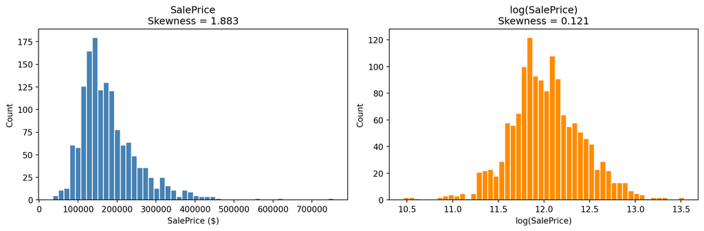

```python
sale_price = df["SalePrice"].astype(float)
log_sale_price = np.log(sale_price)

skew_raw = sale_price.skew()
skew_log = log_sale_price.skew()

fig, axes = plt.subplots(1, 2, figsize=(12, 4))

axes[0].hist(sale_price, bins=50, color="steelblue", edgecolor="white")
axes[0].set_title(f"SalePrice\nSkewness = {skew_raw:.3f}")
axes[0].set_xlabel("SalePrice ($)")
axes[0].set_ylabel("Count")

axes[1].hist(log_sale_price, bins=50, color="darkorange", edgecolor="white")
axes[1].set_title(f"log(SalePrice)\nSkewness = {skew_log:.3f}")
axes[1].set_xlabel("log(SalePrice)")
axes[1].set_ylabel("Count")

plt.tight_layout()
plt.show()
```

**Skewness**:

- `SalePrice` is positively skewed with skewness about 1.883
- `log(SalePrice)` has skewness about 0.121, which is almost symmetric.
- **Conclusion:** Since `log(SalePrice)` is not skewed, logging is preferred for modeling.

```python
cat_cols = df.select_dtypes(include="object").columns.tolist()

rows = []
for col in cat_cols:
    unique_vals = df[col].dropna().unique()
    first_few = ", ".join(str(v) for v in unique_vals[:5])
    rows.append({
        "Column": col,
        "N Unique": df[col].nunique(),
        "First Few Values": first_few
    })

summary_df = pd.DataFrame(rows)
print(summary_df.to_string(index=False))
```

```
       Column  N Unique                              First Few Values
     MSZoning         5                     RL, RM, 'C (all)', FV, RH
       Street         2                                    Pave, Grvl
        Alley         2                                    Grvl, Pave
     LotShape         4                            Reg, IR1, IR2, IR3
  LandContour         4                            Lvl, Bnk, Low, HLS
    Utilities         2                                AllPub, NoSeWa
    LotConfig         5             Inside, FR2, Corner, CulDSac, FR3
    LandSlope         3                                 Gtl, Mod, Sev
 Neighborhood        25   CollgCr, Veenker, Crawfor, NoRidge, Mitchel
   Condition1         9               Norm, Feedr, PosN, Artery, RRAe
   Condition2         8               Norm, Artery, RRNn, Feedr, PosN
     BldgType         5           1Fam, 2fmCon, Duplex, TwnhsE, Twnhs
   HouseStyle         8        2Story, 1Story, 1.5Fin, 1.5Unf, SFoyer
    RoofStyle         6            Gable, Hip, Gambrel, Mansard, Flat
     RoofMatl         8     CompShg, WdShngl, Metal, WdShake, Membran
  Exterior1st        15 VinylSd, MetalSd, 'Wd Sdng', HdBoard, BrkFace
  Exterior2nd        16 VinylSd, MetalSd, 'Wd Shng', HdBoard, Plywood
   MasVnrType         4                  BrkFace, None, Stone, BrkCmn
    ExterQual         4                                Gd, TA, Ex, Fa
    ExterCond         5                            TA, Gd, Fa, Po, Ex
   Foundation         6             PConc, CBlock, BrkTil, Wood, Slab
     BsmtQual         4                                Gd, TA, Ex, Fa
     BsmtCond         4                                TA, Gd, Fa, Po
 BsmtExposure         4                                No, Gd, Mn, Av
 BsmtFinType1         6                       GLQ, ALQ, Unf, Rec, BLQ
 BsmtFinType2         6                       Unf, BLQ, ALQ, Rec, LwQ
      Heating         6                  GasA, GasW, Grav, Wall, OthW
    HeatingQC         5                            Ex, Gd, TA, Fa, Po
   CentralAir         2                                          Y, N
   Electrical         5               SBrkr, FuseF, FuseA, FuseP, Mix
  KitchenQual         4                                Gd, TA, Ex, Fa
   Functional         7                    Typ, Min1, Maj1, Min2, Mod
  FireplaceQu         5                            TA, Gd, Fa, Ex, Po
   GarageType         6     Attchd, Detchd, BuiltIn, CarPort, Basment
 GarageFinish         3                                 RFn, Unf, Fin
   GarageQual         5                            TA, Fa, Gd, Ex, Po
   GarageCond         5                            TA, Fa, Gd, Po, Ex
   PavedDrive         3                                       Y, N, P
       PoolQC         3                                    Ex, Fa, Gd
        Fence         4                      MnPrv, GdWo, GdPrv, MnWw
  MiscFeature         4                        Shed, Gar2, Othr, TenC
     SaleType         9                    WD, New, COD, ConLD, ConLI
SaleCondition         6     Normal, Abnorml, Partial, AdjLand, Alloca
```

```python
ordinal_cols = [
    'LotShape', 'LandSlope',
    'ExterQual', 'ExterCond',
    'BsmtQual', 'BsmtCond', 'BsmtExposure', 'BsmtFinType1', 'BsmtFinType2',
    'HeatingQC', 'KitchenQual', 'Functional', 'FireplaceQu',
    'GarageFinish', 'GarageQual', 'GarageCond',
    'PavedDrive', 'PoolQC', 'Fence'
]

nominal_cols = [col for col in cat_cols if col not in ordinal_cols]

classify_rows = (
    [{'Column': c, 'Type': 'Ordinal'} for c in ordinal_cols] +
    [{'Column': c, 'Type': 'Nominal'} for c in nominal_cols]
)
classify_df = pd.DataFrame(classify_rows)
print(classify_df.to_string(index=False))
```

```
       Column    Type
     LotShape Ordinal
    LandSlope Ordinal
    ExterQual Ordinal
    ExterCond Ordinal
     BsmtQual Ordinal
     BsmtCond Ordinal
 BsmtExposure Ordinal
 BsmtFinType1 Ordinal
 BsmtFinType2 Ordinal
    HeatingQC Ordinal
  KitchenQual Ordinal
   Functional Ordinal
  FireplaceQu Ordinal
 GarageFinish Ordinal
   GarageQual Ordinal
   GarageCond Ordinal
   PavedDrive Ordinal
       PoolQC Ordinal
        Fence Ordinal
     MSZoning Nominal
       Street Nominal
        Alley Nominal
  LandContour Nominal
    Utilities Nominal
    LotConfig Nominal
 Neighborhood Nominal
   Condition1 Nominal
   Condition2 Nominal
     BldgType Nominal
   HouseStyle Nominal
    RoofStyle Nominal
     RoofMatl Nominal
  Exterior1st Nominal
  Exterior2nd Nominal
   MasVnrType Nominal
   Foundation Nominal
      Heating Nominal
   CentralAir Nominal
   Electrical Nominal
   GarageType Nominal
  MiscFeature Nominal
     SaleType Nominal
SaleCondition Nominal
```

**Interpretation**:

The **ordinal** variables are mostly quality, condition, finish, or rating fields, where the labels have a clear order (for example, `ExterQual`, `KitchenQual`, and `GarageFinish`). The remaining categorical variables are **nominal**, since their labels identify categories without a meaningful ranking (for example, `Neighborhood`, `RoofStyle`, and `SaleCondition`). This classification matters because ordinal variables can be encoded using their natural order, while nominal variables should be encoded in a way that does not impose an ranking relationship, such as one-hot encoding.

**1b.** (8 points) Handle missing values, engineer features, encode ordinal columns, set the target, and binary encode the remaining nominal categoricals. Complete all steps:

- Fill **numeric** missing values with `0`; fill **categorical** missing values with `'None'`.
- Create the derived features below, then drop the listed component columns:

| New feature | Formula | Columns to drop |
| --- | --- | --- |
| `TotalSF` | `TotalBsmtSF + 1stFlrSF + 2ndFlrSF` | `TotalBsmtSF`, `1stFlrSF`, `2ndFlrSF` |
| `HouseAge` | `YrSold − YearBuilt` | `YearBuilt` |
| `RemodAge` | `YrSold − YearRemodAdd` | `YearRemodAdd` |

Note: keep `YrSold` (captures market conditions). `PoolArea` and `GarageArea` already encode existence and size — no binary flag needed.

- **Ordinal encode** the quality/condition columns by mapping their string levels to integers. Many features use the scale `Ex > Gd > TA > Fa > Po`, and encoding them as numbers (5–1) preserves the ordering that dummy variable encoding would discard. Use the mappings below:

```python
qual_map = {'None': 0, 'Po': 1, 'Fa': 2, 'TA': 3, 'Gd': 4, 'Ex': 5}
qual_cols = ['ExterQual', 'ExterCond', 'BsmtQual', 'BsmtCond',
             'HeatingQC', 'KitchenQual', 'FireplaceQu',
             'GarageQual', 'GarageCond', 'PoolQC']

other_ordinal = {
    'BsmtExposure': {'None': 0, 'No': 1, 'Mn': 2, 'Av': 3, 'Gd': 4},
    'BsmtFinType1': {'None': 0, 'Unf': 1, 'LwQ': 2, 'Rec': 3, 'BLQ': 4, 'ALQ': 5, 'GLQ': 6},
    'BsmtFinType2': {'None': 0, 'Unf': 1, 'LwQ': 2, 'Rec': 3, 'BLQ': 4, 'ALQ': 5, 'GLQ': 6},
    'GarageFinish': {'None': 0, 'Unf': 1, 'RFn': 2, 'Fin': 3},
    'Fence':        {'None': 0, 'MnWw': 1, 'GdWo': 2, 'MnPrv': 3, 'GdPrv': 4},
    'Functional':   {'Sal': 1, 'Sev': 2, 'Maj2': 3, 'Maj1': 4,
                     'Mod': 5, 'Min2': 6, 'Min1': 7, 'Typ': 8},
    'LotShape':     {'IR3': 1, 'IR2': 2, 'IR1': 3, 'Reg': 4},
    'LandSlope':    {'Sev': 1, 'Mod': 2, 'Gtl': 3},
    'PavedDrive':   {'N': 0, 'P': 1, 'Y': 2},
}
```

- Use log `SalePrice` as your target and drop `SalePrice`. Create dummy variables of the remaining `object`-dtype columns (the nominal categoricals) using `pd.get_dummies(...)`. Print the final feature count and summarize the feature engineered variables (but no need to summarize all of the dummy variables).

```python
print(f"Missing values before filling: {df.isnull().sum().sum()}")
num_cols = df.select_dtypes(include="number").columns
cat_cols_all = df.select_dtypes(include="object").columns

df[num_cols] = df[num_cols].fillna(0)
df[cat_cols_all] = df[cat_cols_all].fillna("None")

print(f"Missing values remaining: {df.isnull().sum().sum()}")
```

```
Missing values before filling: 6965
Missing values remaining: 0
```

```python
display(df.shape)

df["TotalSF"]  = (df["TotalBsmtSF"].astype(float)
                  + df["1stFlrSF"].astype(float)
                  + df["2ndFlrSF"].astype(float))
df["HouseAge"] = df["YrSold"].astype(float) - df["YearBuilt"].astype(float)
df["RemodAge"] = df["YrSold"].astype(float) - df["YearRemodAdd"].astype(float)

df.drop(columns=["TotalBsmtSF", "1stFlrSF", "2ndFlrSF",
                  "YearBuilt", "YearRemodAdd"], inplace=True)

display(df.shape)
```

```
(1460, 81)
```

```
(1460, 79)
```

```python
qual_map = {'None': 0, 'Po': 1, 'Fa': 2, 'TA': 3, 'Gd': 4, 'Ex': 5}
qual_cols = ['ExterQual', 'ExterCond', 'BsmtQual', 'BsmtCond',
             'HeatingQC', 'KitchenQual', 'FireplaceQu',
             'GarageQual', 'GarageCond', 'PoolQC']

other_ordinal = {
    'BsmtExposure': {'None': 0, 'No': 1, 'Mn': 2, 'Av': 3, 'Gd': 4},
    'BsmtFinType1': {'None': 0, 'Unf': 1, 'LwQ': 2, 'Rec': 3, 'BLQ': 4, 'ALQ': 5, 'GLQ': 6},
    'BsmtFinType2': {'None': 0, 'Unf': 1, 'LwQ': 2, 'Rec': 3, 'BLQ': 4, 'ALQ': 5, 'GLQ': 6},
    'GarageFinish': {'None': 0, 'Unf': 1, 'RFn': 2, 'Fin': 3},
    'Fence':        {'None': 0, 'MnWw': 1, 'GdWo': 2, 'MnPrv': 3, 'GdPrv': 4},
    'Functional':   {'Sal': 1, 'Sev': 2, 'Maj2': 3, 'Maj1': 4,
                     'Mod': 5, 'Min2': 6, 'Min1': 7, 'Typ': 8},
    'LotShape':     {'IR3': 1, 'IR2': 2, 'IR1': 3, 'Reg': 4},
    'LandSlope':    {'Sev': 1, 'Mod': 2, 'Gtl': 3},
    'PavedDrive':   {'N': 0, 'P': 1, 'Y': 2},
}

for col in qual_cols:
    df[col] = df[col].map(qual_map)

for col, mapping in other_ordinal.items():
    df[col] = df[col].map(mapping)

display(df.head())
```

|  | Id | MSSubClass | MSZoning | LotFrontage | LotArea | Street | Alley | LotShape | LandContour | Utilities | ... | MiscFeature | MiscVal | MoSold | YrSold | SaleType | SaleCondition | SalePrice | TotalSF | HouseAge | RemodAge |
| --- | --- | --- | --- | --- | --- | --- | --- | --- | --- | --- | --- | --- | --- | --- | --- | --- | --- | --- | --- | --- | --- |
| 0 | 1 | 60 | RL | 65.0 | 8450 | Pave | None | 4 | Lvl | AllPub | ... | None | 0 | 2 | 2008 | WD | Normal | 208500 | 2566.0 | 5.0 | 5.0 |
| 1 | 2 | 20 | RL | 80.0 | 9600 | Pave | None | 4 | Lvl | AllPub | ... | None | 0 | 5 | 2007 | WD | Normal | 181500 | 2524.0 | 31.0 | 31.0 |
| 2 | 3 | 60 | RL | 68.0 | 11250 | Pave | None | 3 | Lvl | AllPub | ... | None | 0 | 9 | 2008 | WD | Normal | 223500 | 2706.0 | 7.0 | 6.0 |
| 3 | 4 | 70 | RL | 60.0 | 9550 | Pave | None | 3 | Lvl | AllPub | ... | None | 0 | 2 | 2006 | WD | Abnorml | 140000 | 2473.0 | 91.0 | 36.0 |
| 4 | 5 | 60 | RL | 84.0 | 14260 | Pave | None | 3 | Lvl | AllPub | ... | None | 0 | 12 | 2008 | WD | Normal | 250000 | 3343.0 | 8.0 | 8.0 |

5 rows × 79 columns

```python
y = np.log(df["SalePrice"].astype(float))
df = df.drop(columns=["SalePrice"])
df = pd.get_dummies(df, drop_first=True)

print(f"Final feature count: {df.shape[1]}")

eng_rows = []
for col in ["TotalSF", "HouseAge", "RemodAge"]:
    eng_rows.append({
        "Feature": col,
        "Mean": round(df[col].mean(), 2),
        "Std": round(df[col].std(),  2),
        "Min": round(df[col].min(),  2),
        "Max": round(df[col].max(),  2),
    })
eng_df = pd.DataFrame(eng_rows)
print(eng_df.to_string(index=False))
```

```
Final feature count: 202
 Feature    Mean    Std   Min     Max
 TotalSF 2567.05 821.71 334.0 11752.0
HouseAge   36.55  30.25   0.0   136.0
RemodAge   22.95  20.64  -1.0    60.0
```

**Summary**:

- `TotalSF` has an average of about 2567.05 sq ft and ranges from 334.0 to 11752.0, showing substantial variation (std of 821.71 sq ft) in home size.
- `HouseAge` has a mean of about 36.55 years with values from 0 to 136.0, with a large standard deviation of 30.25 years.
- `RemodAge` has a mean of about 22.95 years and ranges from -1.0 to 60.0, with a standard deviation of 20.64 years, indicating that many homes had not been remodeled for a long time since the sale year.

**1c.** (3 points) Split into 70% train and 30% test (set `random_state=370`). Print the shapes of `X_train`, `X_test`, `y_train`, `y_test`. Report the mean and standard deviation of `y_train` and `y_test`.

```python
from sklearn.model_selection import train_test_split

X = df.values.astype(float)

X_train, X_test, y_train, y_test = train_test_split(
    X, y, test_size=0.30, random_state=370
)

print(f"X_train: {X_train.shape}")
print(f"X_test: {X_test.shape}")
print(f"y_train: {y_train.shape}")
print(f"y_test: {y_test.shape}")

results = [
    {'Set': 'y_train', 'Mean': round(y_train.mean(), 4), 'Std': round(y_train.std(), 4)},
    {'Set': 'y_test',  'Mean': round(y_test.mean(),  4), 'Std': round(y_test.std(),  4)},
]
print(pd.DataFrame(results).to_string(index=False))
```

```
X_train: (1022, 202)
X_test: (438, 202)
y_train: (1022,)
y_test: (438,)
    Set    Mean    Std
y_train 12.0296 0.4004
 y_test 12.0110 0.3974
```

**Summary:**

The train set has 1022 rows and 202 columns, and the test set has 438 rows and 202 columns. The mean of the target in the train set is 12.0296 and the standard deviation is 0.4004. The mean of the target variable in the test set is 12.011 and the standard deviation is 0.3974.

### Question 2: Baseline — Ridge Regression (10 points)

**2** (10 points) Write a brief description of what ridge regression is, and then fit `RidgeCV` model using `alphas=np.logspace(-3, 3, 50)` and `cv=5`. Explain what you are tuning and report the chosen `alpha_`. Then estimate the 5-fold CV RMSE using the chosen alpha. The on the test set report R$^2$ and RMSE (log scale) and convert log-scale predictions back to dollars to report test R$^2$ and RMSE in dollars. Interpret the model performance metrics.

**Ridge Regression**:

It is a linear regression method that adds an L2 penalty to the loss function, shrinking coefficient estimates toward zero. This helps reduce overfitting and multicollinearity by trading a small amount of bias for lower variance.

```python
from sklearn.linear_model import RidgeCV, Ridge
from sklearn.model_selection import cross_val_score
from sklearn.metrics import mean_squared_error, r2_score
from sklearn.preprocessing import StandardScaler

scaler = StandardScaler()
X_train_sc = scaler.fit_transform(X_train)
X_test_sc  = scaler.transform(X_test)

ridge_cv = RidgeCV(alphas=np.logspace(-3, 3, 50), cv=5)
ridge_cv.fit(X_train_sc, y_train)

print(f"Chosen alpha: {ridge_cv.alpha_:.4f}")

cv_scores = cross_val_score(
    Ridge(alpha=ridge_cv.alpha_),
    X_train_sc, y_train,
    cv=5,
    scoring='neg_mean_squared_error'
)
cv_rmse = np.sqrt(-cv_scores.mean())
print(f"5-fold CV RMSE (log scale): {cv_rmse:.4f}")

y_pred_log = ridge_cv.predict(X_test_sc)
test_r2_log  = r2_score(y_test, y_pred_log)
test_rmse_log = np.sqrt(mean_squared_error(y_test, y_pred_log))
print(f"\nTest R^2 (log scale): {test_r2_log:.4f}")
print(f"Test RMSE (log scale): {test_rmse_log:.4f}")

y_pred_dollars = np.exp(y_pred_log)
y_test_dollars = np.exp(y_test)
test_r2_dollars   = r2_score(y_test_dollars, y_pred_dollars)
test_rmse_dollars = np.sqrt(mean_squared_error(y_test_dollars, y_pred_dollars))
print(f"\nTest R^2 (dollars): {test_r2_dollars:.4f}")
print(f"Test RMSE (dollars): ${test_rmse_dollars:,.2f}")
```

```
Chosen alpha: 244.2053
5-fold CV RMSE (log scale): 0.1357

Test R^2 (log scale): 0.8433
Test RMSE (log scale): 0.1572

Test R^2 (dollars): 0.3349
Test RMSE (dollars): $64,459.61
```

**Interpretation**:

In `RidgeCV`, the hyperparameter being tuned is `alpha`, which controls the strength of the L2 penalty. Larger values of `alpha` shrink the regression coefficients more strongly, which can reduce overfitting but may also introduce more bias. The chosen `alpha` is 244.2053, indicates that a fairly strong amount of regularization gave the best 5-fold cross-validation performance.

The 5-fold CV RMSE on the log scale is 0.1357, which is reasonably close to the test RMSE of 0.1572, suggesting that the model generalizes fairly well and is not severely overfitting. On the log scale, the test R$^2$ is 0.8433, so the ridge model explains a large share of the variation in logged house prices. After converting predictions back to dollars, the test RMSE is about 64459.61 dollars, and the R$^2$ in dollars drops to 0.3349. This lower R$^2$ on the original scale shows that errors become much larger in dollar scale.

### Question 3: Random Forest (12 points)

**3a.** (10 points) Tune a `RandomForestRegressor` by trying two different values for `n_estimators`, three different `max_features`, two different `max_depth` values, and two different `min_samples_leaf` values (24 combinations). Write a function `fit_rf_cv(n_est, max_feat, max_d, min_leaf)` that fits the model and returns the CV RMSE, then run the grid search both serially and in parallel with `Parallel(n_jobs=4)`. Keep `random_state=370` and `n_jobs=1` inside the model. Report serial time and speedup time. Report the best combination in a table. Then fit the best Random Forest on the full training set, report test R$^2$ and RMSE (log scale and dollars). Interpret and discuss.

```python
import time
import itertools
from joblib import Parallel, delayed
from sklearn.ensemble import RandomForestRegressor

n_estimators_grid  = [100, 300]
max_features_grid  = ['sqrt', 0.33, 0.5]
max_depth_grid     = [10, 20]
min_samples_leaf_grid = [1, 5]

param_combinations = list(itertools.product(
    n_estimators_grid, max_features_grid, max_depth_grid, min_samples_leaf_grid
))
print(f"Total combinations: {len(param_combinations)}")

def fit_rf_cv(n_est, max_feat, max_d, min_leaf):
    rf = RandomForestRegressor(
        n_estimators=n_est,
        max_features=max_feat,
        max_depth=max_d,
        min_samples_leaf=min_leaf,
        random_state=370,
        n_jobs=1
    )
    scores = cross_val_score(
        rf, X_train_sc, y_train,
        cv=5,
        scoring='neg_mean_squared_error',
        n_jobs=1
    )
    cv_rmse = np.sqrt(-scores.mean())
    return (n_est, max_feat, max_d, min_leaf, cv_rmse)
```

```
Total combinations: 24
```

```python
t0 = time.time()
serial_results = [fit_rf_cv(*p) for p in param_combinations]
time_serial = time.time() - t0
print(f"Serial grid search: {time_serial:.2f}s  ({len(param_combinations)} combinations)")

t0 = time.time()
parallel_results = Parallel(n_jobs=4)(
    delayed(fit_rf_cv)(*p) for p in param_combinations
)
time_parallel = time.time() - t0
print(f"Parallel grid search (4 workers): {time_parallel:.2f}s")
print(f"Speedup: {time_serial / time_parallel:.2f}x")

best = min(parallel_results, key=lambda x: x[4])
best_row = pd.DataFrame([{
    'n_estimators': best[0], 'max_features': best[1],
    'max_depth':    best[2], 'min_samples_leaf': best[3],
    'CV RMSE':      round(best[4], 4)
}])
print("\nBest combination by CV RMSE:")
print(best_row.to_string(index=False))
```

```
Serial grid search: 50.29s  (24 combinations)
Parallel grid search (4 workers): 15.99s
Speedup: 3.15x

Best combination by CV RMSE:
 n_estimators  max_features  max_depth  min_samples_leaf  CV RMSE
          100          0.33         10                 1   0.1411
```

```python
best_rf = RandomForestRegressor(
    n_estimators=100,
    max_features=0.33,
    max_depth=10,
    min_samples_leaf=1,
    random_state=370,
    n_jobs=1
)
best_rf.fit(X_train_sc, y_train)

y_pred_rf_log = best_rf.predict(X_test_sc)
rf_test_r2_log   = r2_score(y_test, y_pred_rf_log)
rf_test_rmse_log = np.sqrt(mean_squared_error(y_test, y_pred_rf_log))

y_pred_rf_dollars = np.exp(y_pred_rf_log)
rf_test_r2_dollars   = r2_score(np.exp(y_test), y_pred_rf_dollars)
rf_test_rmse_dollars = np.sqrt(mean_squared_error(np.exp(y_test), y_pred_rf_dollars))

print(f"\nTest R^2 (log scale): {rf_test_r2_log:.4f}")
print(f"Test RMSE (log scale): {rf_test_rmse_log:.4f}")
print(f"\nTest R^2 (dollars): {rf_test_r2_dollars:.4f}")
print(f"Test RMSE (dollars): ${rf_test_rmse_dollars:,.2f}")
```

```
Test R^2 (log scale): 0.8848
Test RMSE (log scale): 0.1347

Test R^2 (dollars): 0.8713
Test RMSE (dollars): $28,353.21
```

**Interpretation**:

The parallel grid search completed in about 15.99 seconds compared to 50.29 seconds for the serial version, giving a speedup of 3.15x. This is close to the theoretical maximum of `4x` for four workers, since the 24 hyperparameter combinations can be evaluated independently.

On the test set, the test R$^2$ is 0.8848 on the log scale and 0.8713 on the dollar scale. The test RMSE is 0.1347 on the log scale and about 28353.21 in dollars. These suggest that the final tuned random forest explains a significant large amount of the variation in house sale prices and predicts substantially better than the baseline model, especially on the dollar scale with a significant lower RMSE.

**3b.** (2 points) Plot the top 15 features. Do the most important features make intuitive sense for predicting house prices?

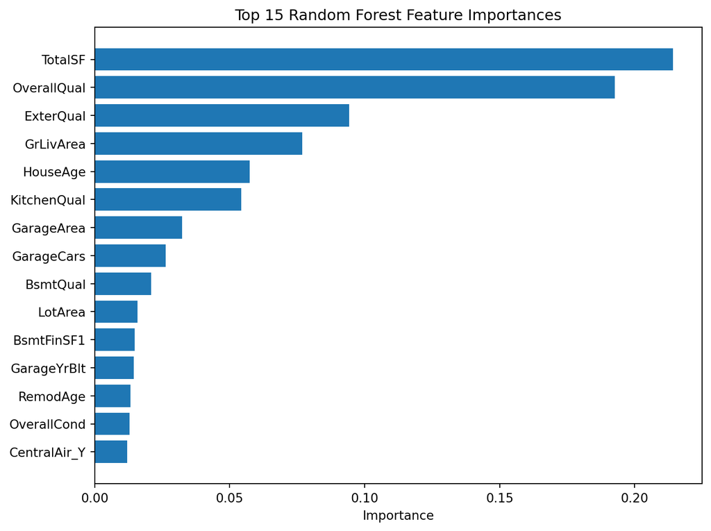

```python
feature_names = df.columns.tolist()

imp_df = pd.DataFrame({
    'feature':    feature_names,
    'importance': best_rf.feature_importances_
}).sort_values('importance', ascending=False).head(15)

imp_df = imp_df.sort_values('importance', ascending=True)
imp_df['feature'] = pd.Categorical(imp_df['feature'], categories=imp_df['feature'])

fig, ax = plt.subplots(figsize=(8, 6))
ax.barh(imp_df['feature'], imp_df['importance'])
ax.set_xlabel('Importance')
ax.set_title('Top 15 Random Forest Feature Importances')
plt.tight_layout()
plt.show()
```

**Summary:**

The most important features mostly reflect overall house size, build quality, house age, and garage characteristics. In general, these are all factors closely related to housing prices. Hence, these important features make intuitive sense for predicting house prices.

### Question 4: XGBoost with Parallel Hyperparameter Search (12 points)

**4a.** (8 points) Define a hyperparameter grid with **at least 3 values** for each of `max_depth`, `learning_rate`, `n_estimators`, and `subsample` (minimum 81 combinations). Print the total number of combinations. Write a function `fit_xgb_cv(params)` that builds an `XGBRegressor` with the given `params` (plus `n_jobs=1`, `random_state=370`, `verbosity=0`), runs 5-fold CV with `scoring='neg_root_mean_squared_error'` and `n_jobs=1` on `(X_train, y_train)`, and returns `(params, mean_cv_rmse)`. Run the grid search both serially and in parallel with `Parallel(n_jobs=4)`. Report serial time and parallel speedup. Find the best hyperparameter combination (lowest mean CV RMSE), refit on the full training set, and report test R$^2$ and RMSE in log scale and dollars. Interpret and discuss.

```python
import xgboost as xgb

param_grid_xgb = [
    {'max_depth': d, 'learning_rate': lr, 'n_estimators': n, 'subsample': ss}
    for d  in [3, 5, 7]
    for lr in [0.01, 0.1, 0.3]
    for n  in [50, 100, 200]
    for ss in [0.6, 0.8, 1.0]
]
print(f"Total hyperparameter combinations: {len(param_grid_xgb)}")

def fit_xgb_cv(params):
    model = xgb.XGBRegressor(
        **params,
        n_jobs=1,
        random_state=370,
        verbosity=0
    )
    scores = cross_val_score(
        model,
        X_train_sc, y_train,
        cv=5,
        scoring='neg_root_mean_squared_error',
        n_jobs=1
    )
    return (params, -scores.mean())
```

```
Total hyperparameter combinations: 81
```

```python
t0 = time.time()
serial_results_xgb = [fit_xgb_cv(p) for p in param_grid_xgb]
time_serial_xgb = time.time() - t0
print(f"Serial grid search: {time_serial_xgb:.2f}s  ({len(param_grid_xgb)} combinations)")

t0 = time.time()
parallel_results_xgb = Parallel(n_jobs=4)(
    delayed(fit_xgb_cv)(p) for p in param_grid_xgb
)
time_parallel_xgb = time.time() - t0
print(f"Parallel grid search (4 workers): {time_parallel_xgb:.2f}s")
print(f"Speedup: {time_serial_xgb / time_parallel_xgb:.2f}x")

best_xgb = min(parallel_results_xgb, key=lambda x: x[1])
best_xgb_row = pd.DataFrame([{**best_xgb[0], 'CV RMSE': round(best_xgb[1], 4)}])
print("\nBest combination by CV RMSE:")
print(best_xgb_row.to_string(index=False))
```

```
Serial grid search: 51.17s  (81 combinations)
Parallel grid search (4 workers): 13.91s
Speedup: 3.68x

Best combination by CV RMSE:
 max_depth  learning_rate  n_estimators  subsample  CV RMSE
         3            0.1           200        0.6   0.1307
```

```python
best_xgb_model = xgb.XGBRegressor(
    max_depth=3,
    learning_rate=0.1,
    n_estimators=200,
    subsample=0.6,
    n_jobs=1,
    random_state=370,
    verbosity=0
)
best_xgb_model.fit(X_train_sc, y_train)

y_pred_xgb_log = best_xgb_model.predict(X_test_sc)
xgb_test_r2_log   = r2_score(y_test, y_pred_xgb_log)
xgb_test_rmse_log = np.sqrt(mean_squared_error(y_test, y_pred_xgb_log))

y_pred_xgb_dollars = np.exp(y_pred_xgb_log)
xgb_test_r2_dollars   = r2_score(np.exp(y_test), y_pred_xgb_dollars)
xgb_test_rmse_dollars = np.sqrt(mean_squared_error(np.exp(y_test), y_pred_xgb_dollars))

print(f"Test R^2 (log scale): {xgb_test_r2_log:.4f}")
print(f"Test RMSE (log scale): {xgb_test_rmse_log:.4f}")
print(f"\nTest R^2 (dollars): {xgb_test_r2_dollars:.4f}")
print(f"Test RMSE (dollars): ${xgb_test_rmse_dollars:,.2f}")
```

```
Test R^2 (log scale): 0.8982
Test RMSE (log scale): 0.1266

Test R^2 (dollars): 0.8876
Test RMSE (dollars): $26,494.95
```

**Interpretation**:

The parallel grid search completed in about 13.91 seconds compared to 51.17 seconds for the serial version, giving a speedup of 3.68x. As with the random forest, this speedup is close to the theoretical maximum of `4x` for four workers, since each of the 81 combinations can be evaluated independently.

On the test set,the test R$^2$ is 0.8982 on the log scale and 0.8876 on the dollar scale, and the test RMSE is 0.1266 on the log scale and about 26494.95 in dollars. Compared to the random forest, XGBoost achieves a lower prediction error on the dollar scale. This is consistent that gradient boosting tends to outperform random forests on structured tabular data when model is tuned.

**4b.** (2 points) Now try **inner-level parallelism**: write `fit_xgb_cv_inner(params)` that uses `n_jobs=4` on the `XGBRegressor` itself (so each model uses 4 threads internally) and `n_jobs=1` in `cross_val_score`, then run the grid search serially. Report wall-clock time and compare it to the serial (`n_jobs=1`) and outer-parallel (`Parallel(n_jobs=4)`) approaches from 4a. Which strategy is fastest and why?

```python
def fit_xgb_cv_inner(params):
    model = xgb.XGBRegressor(
        **params,
        n_jobs=4,
        random_state=370,
        verbosity=0
    )
    scores = cross_val_score(
        model,
        X_train_sc, y_train,
        cv=5,
        scoring='neg_root_mean_squared_error',
        n_jobs=1
    )
    return (params, -scores.mean())

t0 = time.time()
inner_results = [fit_xgb_cv_inner(p) for p in param_grid_xgb]
time_inner = time.time() - t0
print(f"Inner-parallel serial grid search (n_jobs=4 inside model): {time_inner:.2f}s")
print(f"Serial   (n_jobs=1 everywhere): {time_serial_xgb:.2f}s")
print(f"Parallel (Parallel n_jobs=4): {time_parallel_xgb:.2f}s")
```

```
Inner-parallel serial grid search (n_jobs=4 inside model): 50.63s
Serial   (n_jobs=1 everywhere): 51.17s
Parallel (Parallel n_jobs=4): 13.91s
```

**Interpretation**:

The outer-parallel strategy is the fastest. Although giving each XGBoost model 4 threads helps a little bit, the grid search still evaluates the 81 hyperparameter combinations one after another, so the overall procedure remains mostly sequential. In contrast, outer-level parallelism distributes different hyperparameter combinations across workers at the same time, which is much more effective.

**4c.** (2 points) Plot the top 15 features. How do they compare to the random forest variable importance?

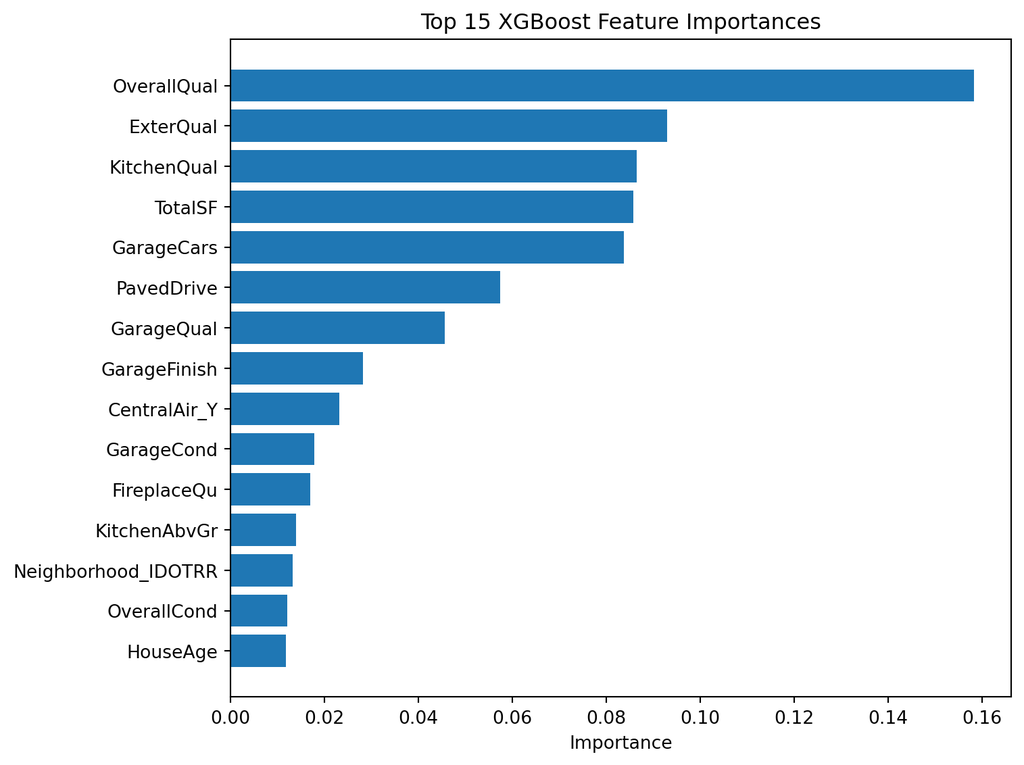

```python
xgb_imp_df = pd.DataFrame({
    'feature':    df.columns.tolist(),
    'importance': best_xgb_model.feature_importances_
}).sort_values('importance', ascending=False).head(15)

xgb_imp_df = xgb_imp_df.sort_values('importance', ascending=True)
xgb_imp_df['feature'] = pd.Categorical(xgb_imp_df['feature'], categories=xgb_imp_df['feature'])

fig, ax = plt.subplots(figsize=(8, 6))
ax.barh(xgb_imp_df['feature'], xgb_imp_df['importance'])
ax.set_xlabel('Importance')
ax.set_title('Top 15 XGBoost Feature Importances')
plt.tight_layout()
plt.show()
```

**Summary:**

Both models agree that overall quality and exterior quality are among the most important predictors of house price. The key difference is that XGBoost concentrates much more importance on quality-related ratings (e.g., `ExterQual`, `KitchenQual`, `GarageQual`, `GarageFinish`, `PavedDrive`), whereas the Random Forest spreads importance more broadly across continuous size and age features such as `TotalSF`, `GrLivArea`, `GarageArea`, and `HouseAge`. Hence, XGBoost sequentially corrects residuals and tends to focus on a few highly discriminative ordinal features, while the Random Forest model averaging over many trees captures a larger variety of signals.

### Question 5: Model Comparison (6 points)

**5a.** (6 points) Assemble a summary table with columns: `Model`, `Best CV RMSE (log)`, `Test RMSE (log)`, `Test RMSE ($)`, `Test R^2`. Include Ridge, Random Forest, and XGBoost. On a single figure with three side-by-side panels, plot predicted vs actual `SalePrice` (in dollars) for Ridge, Random Forest, and XGBoost. Add a 1-to-1 reference line to each panel. Interpret and discuss your findings.

```python
rf_best_cv_rmse  = best[4]
xgb_best_cv_rmse = best_xgb[1]

summary_df = pd.DataFrame([
    {
        'Model': 'Ridge',
        'Best CV RMSE (log)': round(cv_rmse,            4),
        'Test RMSE (log)': round(test_rmse_log,       4),
        'Test RMSE ($)': round(test_rmse_dollars,   2),
        'Test R^2': round(test_r2_log,         4),
    },
    {
        'Model': 'Random Forest',
        'Best CV RMSE (log)': round(rf_best_cv_rmse,     4),
        'Test RMSE (log)': round(rf_test_rmse_log,    4),
        'Test RMSE ($)': round(rf_test_rmse_dollars, 2),
        'Test R^2': round(rf_test_r2_log,      4),
    },
    {
        'Model': 'XGBoost',
        'Best CV RMSE (log)': round(xgb_best_cv_rmse,    4),
        'Test RMSE (log)': round(xgb_test_rmse_log,   4),
        'Test RMSE ($)': round(xgb_test_rmse_dollars, 2),
        'Test R^2': round(xgb_test_r2_log,     4),
    },
])
print(summary_df.to_string(index=False))
```

```
        Model  Best CV RMSE (log)  Test RMSE (log)  Test RMSE ($)  Test R^2
        Ridge              0.1357           0.1572       64459.61    0.8433
Random Forest              0.1411           0.1347       28353.21    0.8848
      XGBoost              0.1307           0.1266       26494.95    0.8982
```

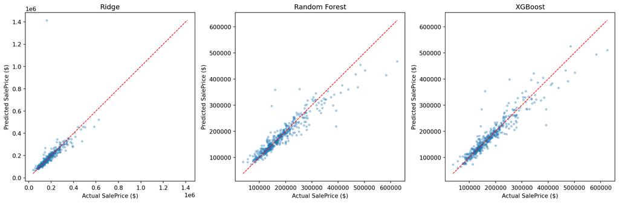

```python
y_test_dollars = np.exp(y_test)

models      = ['Ridge', 'Random Forest', 'XGBoost']
pred_list   = [y_pred_dollars, y_pred_rf_dollars, y_pred_xgb_dollars]

fig, axes = plt.subplots(1, 3, figsize=(15, 5))

for ax, name, preds in zip(axes, models, pred_list):
    ax.scatter(y_test_dollars, preds, alpha=0.3, s=10)
    lims = [
        min(y_test_dollars.min(), preds.min()),
        max(y_test_dollars.max(), preds.max()),
    ]
    ax.plot(lims, lims, 'r--', linewidth=1)
    ax.set_xlabel('Actual SalePrice ($)')
    ax.set_ylabel('Predicted SalePrice ($)')
    ax.set_title(name)

plt.tight_layout()
plt.show()
```

**Interpretation**:

According to the plot, the XGBoost panel shows points clustered most tightly around the 1-to-1 line, indicating the most accurate overall predictions. The Random Forest one also show points clustered close to the line, but with a little bit more deviation, especially for higher-priced homes. The Ridge plot shows a concentration of points at lower prices and missing the higher priced homes, along with one significant outlier.

## Part 2: Parallel Functions

### Question 6: Monte Carlo pi Estimation (12 points)

**6a.** (4 points) Write `estimate_pi(N, seed=None)` that:

1. Draws `N` uniform random points in [0,1] × [0,1]
2. Counts how many satisfy x² + y² ≤ 1 (inside the unit circle)
3. Returns 4 × (count inside) / N

Run it with N = 1,000, 100,000, and 1,000,000. For each, report the estimate, the absolute error from `np.pi`, and the serial time. How does accuracy scale with N? How does run time scale?

```python
def estimate_pi(N, seed=None):
    rng = np.random.default_rng(seed)
    x = rng.uniform(0, 1, N)
    y = rng.uniform(0, 1, N)
    inside = np.sum(x**2 + y**2 <= 1)
    return 4 * inside / N

rows = []
for N in [1_000, 100_000, 1_000_000]:
    t0 = time.perf_counter()
    est = estimate_pi(N, seed=370)
    elapsed = time.perf_counter() - t0
    rows.append({
        'N':          N,
        'Estimate':   round(est, 6),
        'Abs Error':  round(abs(est - np.pi), 6),
        'Time (s)':   round(elapsed, 6),
    })

print(pd.DataFrame(rows).to_string(index=False))
```

```
      N  Estimate  Abs Error  Time (s)
   1000  3.080000   0.061593  0.000288
 100000  3.145680   0.004087  0.002936
1000000  3.143388   0.001795  0.014349
```

**Summary:**

- The absolute error decreases as `N` increases, so the estimate becomes more accurate.
- The run time increases as `N` increases because more simulated points must be generated and checked.

**6b.** (4 points) Run `estimate_pi(N=100_000)` serially with seeds 0–1999 (2,000 runs). Record the serial time. Report the mean and standard deviation of the estimates.

```python
seeds = list(range(2000))

t0 = time.perf_counter()
serial_estimates = [estimate_pi(N=100_000, seed=s) for s in seeds]
t_serial_6b = time.perf_counter() - t0

mean_est = np.mean(serial_estimates)
std_est  = np.std(serial_estimates)

print(f"Serial time: {t_serial_6b:.4f} s")
print(f"Mean estimate: {mean_est:.6f}")
print(f"Std deviation: {std_est:.6f}")
print(f"Abs error of mean: {abs(mean_est - np.pi):.6f}")
```

```
Serial time: 2.0216 s
Mean estimate: 3.141443
Std deviation: 0.005389
Abs error of mean: 0.000150
```

**Summary:**

Running 2,000 independent Monte Carlo estimates with `N = 100,000` serially takes about 2.02 seconds. The mean estimate is 3.141443, with a standard deviation of approximately 0.005389. The absolute error of the mean is very small (around 0.00015), showing that averaging many independent estimates further improves the accuracy.

**6c.** (4 points) Repeat 6b in parallel with `Parallel(n_jobs=4, prefer="threads")`. Report speedup. Verify the mean estimate is within 0.001 of the serial result. Why is `prefer="threads"` a good choice here? Is the speedup closer to 4x compared to the XGBoost grid search? Why?

```python
t0 = time.perf_counter()
parallel_estimates = Parallel(n_jobs=4, prefer="threads")(
    delayed(estimate_pi)(N=100_000, seed=s) for s in seeds
)
t_parallel_6c = time.perf_counter() - t0

mean_par = np.mean(parallel_estimates)
speedup  = t_serial_6b / t_parallel_6c

print(f"Parallel time : {t_parallel_6c:.4f} s")
print(f"Serial time: {t_serial_6b:.4f} s")
print(f"Speedup: {speedup:.2f}x")
print(f"Mean (parallel): {mean_par:.6f}")
print(f"Mean (serial): {mean_est:.6f}")
```

```
Parallel time : 0.5474 s
Serial time: 2.0216 s
Speedup: 3.69x
Mean (parallel): 3.141443
Mean (serial): 3.141443
```

**Summary:**

The difference between the parallel and serial mean estimates is 0.0 after rounding, so within 0.001.

`prefer="threads"` is good because the core computation relies heavily on NumPy operations. NumPy releases the Global Interpreter Lock (GIL) during these operations, allowing Python threads to execute truly in parallel. Threads have much lower overhead than processes, making them ideal for this task.

### Question 7: Bootstrap Confidence Interval for Test RMSE (12 points)

Bootstrapping gives a confidence interval for any model metric without making distributional assumptions. Each resample is independent, making it naturally parallel.

**7a.** (4 points) Using the best XGBoost model fitted in Question 4, write a function `boot_rmse(idx)` that:

1. Selects rows `idx` from `X_test` and `y_test` (resample with replacement)
2. Predicts with the best XGBoost model
3. Returns the RMSE on the resample (log scale)

```python
def boot_rmse(idx):
    X_resample = X_test_sc[idx]
    y_resample = y_test.iloc[idx]
    y_pred     = best_xgb_model.predict(X_resample)
    return np.sqrt(mean_squared_error(y_resample, y_pred))
```

**7b.** (4 points) Generate 1,000 bootstrap index arrays using a fixed random seed, run `boot_rmse` serially, and compute the 95% percentile bootstrap CI for test RMSE. Time the computation.

```python
rng_boot = np.random.default_rng(370)
n_test   = len(y_test)
boot_idx = [rng_boot.choice(n_test, size=n_test, replace=True) for _ in range(1000)]

t0 = time.perf_counter()
serial_rmses = [boot_rmse(idx) for idx in boot_idx]
t_serial_7b  = time.perf_counter() - t0

ci_low_7b, ci_high_7b = np.percentile(serial_rmses, [2.5, 97.5])

print(f"Serial time: {t_serial_7b:.4f} s")
print(f"95% CI: ({ci_low_7b:.4f}, {ci_high_7b:.4f})")
```

```
Serial time: 0.6883 s
95% CI: (0.1076, 0.1469)
```

**Summary:**

Running 1,000 bootstrap resamples serially takes about 0.69 seconds. The resulting 95% bootstrap confidence interval for the test RMSE (on the log scale) is 0.1076 to 0.1469.

**7c.** (4 points) Run the same 1,000 bootstrap resamples in parallel with `Parallel(n_jobs=4, prefer="threads")`. Compare the CI to 7b and report speedup. Why is `prefer="threads"` important here, what happens if you use the default process backend instead? Do the serial and parallel CIs agree? Should they, given that both use the same pre-generated index arrays?

```python
t0 = time.perf_counter()
parallel_rmses = Parallel(n_jobs=4, prefer="threads")(
    delayed(boot_rmse)(idx) for idx in boot_idx
)
t_parallel_7c = time.perf_counter() - t0

speedup_7c = t_serial_7b / t_parallel_7c
ci_low_7c, ci_high_7c = np.percentile(parallel_rmses, [2.5, 97.5])

print(f"Parallel time: {t_parallel_7c:.4f} s")
print(f"Serial time: {t_serial_7b:.4f} s")
print(f"Speedup: {speedup_7c:.2f}x")
print(f"95% CI (parallel): ({ci_low_7c:.4f}, {ci_high_7c:.4f})")
print(f"95% CI (serial): ({ci_low_7b:.4f}, {ci_high_7b:.4f})")
```

```
Parallel time: 0.3570 s
Serial time: 0.6883 s
Speedup: 1.93x
95% CI (parallel): (0.1076, 0.1469)
95% CI (serial): (0.1076, 0.1469)
```

**Summary:**

Running the 1,000 bootstrap resamples in parallel reduces the wall-clock time from 0.69 seconds to 0.36 seconds, for a speedup of about 1.93x.

Using `prefer="threads"` is important here because each task is fairly small, so threads avoid the extra process startup and serialization overhead that comes with the default process backend. If the default process backend were used, `joblib` would need to send objects like `best_xgb_model`, `X_test_sc`, and the bootstrap indices across processes, which would usually make this workload less efficient. The 95% bootstrap CI from the parallel run is 0.1076 to 0.1469, which matches the serial CI of 0.1076 to 0.1469 and they should match because both versions evaluate the same deterministic `boot_rmse` function on the same pre-generated `boot_idx` arrays.